# Assignment 1 VIS

Ryan Johnson

9/15/2020

```r
hh_vars_2018 <- pums_variables %>%
  distinct(year, survey, var_code,
           var_label, data_type, level) %>%
  filter(level == "housing", year == 2018, survey == "acs1")
```

### Defining the data set

Below, I define a data set including the following variables:

- **HINCP** - Household income - continuous
- **RNTP** - Monthly rent ($) - continuous
- **NP** - Number of people per household - continuous
- **BDSP** - Number of bedrooms per household - continuous
- **HHT_label** - Household type - categorical
- **BLDG_AGE_dec** - Age of building in decades - categorical

This sample began with all Texas responses from the 2018 ACS 1-year survey, and was further narrowed to include only those households with *some* household income and monthly rent payment. Then, I added a filter to narrow my data to only those responses collected in Travis County.

```r
Travis_puma_rentals <- get_pums(variables = c(
                                      "PUMA",
                                      "HINCP",
                                      "RNTP",
                                      "NP",
                                      "BDSP",
                                      "HHT",
                                      "YBL"),
                        state = "TX",
                        year = 2018,
                        survey = "acs1",
                        recode = TRUE) %>%
     mutate(PUMA = as.numeric(PUMA)) %>%
     mutate(BLDG_AGE_dec = case_when(
      YBL_label == "1939 or earlier" ~ 8,
      YBL_label == "1940 to 1949" ~ 7,
      YBL_label == "1950 to 1959" ~ 6,
      YBL_label == "1960 to 1969" ~ 5,
      YBL_label == "1970 to 1979" ~ 4,
      YBL_label == "1980 to 1989" ~ 3,
      YBL_label == "1990 to 1999" ~ 2,
      YBL_label == "2000 to 2004" ~ 1,
      YBL_label == "2005" ~ 1,
      YBL_label == "2006" ~ 1,
      YBL_label == "2007" ~ 1,
      YBL_label == "2008" ~ 1,
      YBL_label == "2009" ~ 1,
      YBL_label == "2010" ~ 0,
      YBL_label == "2011" ~ 0,
      YBL_label == "2012" ~ 0,
      YBL_label == "2013" ~ 0,
      YBL_label == "2014" ~ 0,
      YBL_label == "2015" ~ 0,
      YBL_label == "2016" ~ 0,
      YBL_label == "2017" ~ 0,
      YBL_label == "2018" ~ 0,)) %>%
     filter(HINCP > 0, RNTP > 0, PUMA > 05300 & PUMA < 05310) %>%
     select(HINCP, RNTP, NP, BDSP, HHT_label, BLDG_AGE_dec)
```

Defining a subset of the above data, representing only the Central Austin PUMA:

```r
Central_austin_rentals <- get_pums(variables = c(
                                      "PUMA",
                                      "HINCP",
                                      "RNTP",
                                      "NP",
                                      "BDSP",
                                      "HHT",
                                      "YBL"),
                        state = "TX",
                        year = 2018,
                        survey = "acs1",
                        recode = TRUE) %>%
     mutate(PUMA = as.numeric(PUMA)) %>%
     mutate(BLDG_AGE_dec = case_when(
      YBL_label == "1939 or earlier" ~ 8,
      YBL_label == "1940 to 1949" ~ 7,
      YBL_label == "1950 to 1959" ~ 6,
      YBL_label == "1960 to 1969" ~ 5,
      YBL_label == "1970 to 1979" ~ 4,
      YBL_label == "1980 to 1989" ~ 3,
      YBL_label == "1990 to 1999" ~ 2,
      YBL_label == "2000 to 2004" ~ 1,
      YBL_label == "2005" ~ 1,
      YBL_label == "2006" ~ 1,
      YBL_label == "2007" ~ 1,
      YBL_label == "2008" ~ 1,
      YBL_label == "2009" ~ 1,
      YBL_label == "2010" ~ 0,
      YBL_label == "2011" ~ 0,
      YBL_label == "2012" ~ 0,
      YBL_label == "2013" ~ 0,
      YBL_label == "2014" ~ 0,
      YBL_label == "2015" ~ 0,
      YBL_label == "2016" ~ 0,
      YBL_label == "2017" ~ 0,
      YBL_label == "2018" ~ 0,)) %>%
     filter(HINCP > 0, RNTP > 0, PUMA == 05306) %>%
     select(HINCP, RNTP, NP, BDSP, HHT_label, BLDG_AGE_dec)
```

### 1.Scatterplot showing multiple variables:

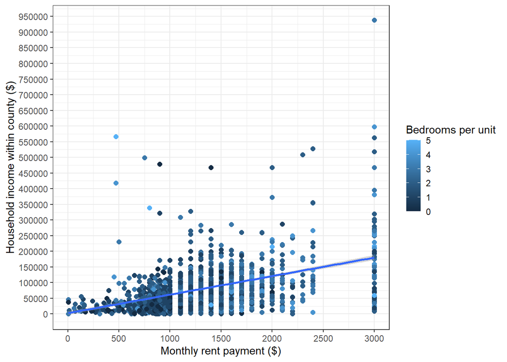

```r
ggplot(Travis_puma_rentals,
       aes(x = RNTP,
           y = HINCP,
           color = BDSP)) +
  geom_point(size = 2) +
  stat_smooth(method = "lm") +
  scale_size_continuous(name = "Austin rent and income") +
  scale_x_continuous(name = "Monthly rent payment ($)",
                     breaks = seq(0, 10000, by = 500),
                     labels = paste(seq(0, 10000, by = 500))) +
  scale_y_continuous(name = "Household income within county ($)",
                     breaks = seq(0, 1000000, by = 50000)) +
  scale_color_continuous(name = "Bedrooms per unit") +
  theme_bw() +
  theme(legend.key.size = unit(0.5, "cm")) +
  ggsave("A_0_scatterplot.png", width = 5, height = 5)
```

### 2. Scatterplot showing rent and household income:

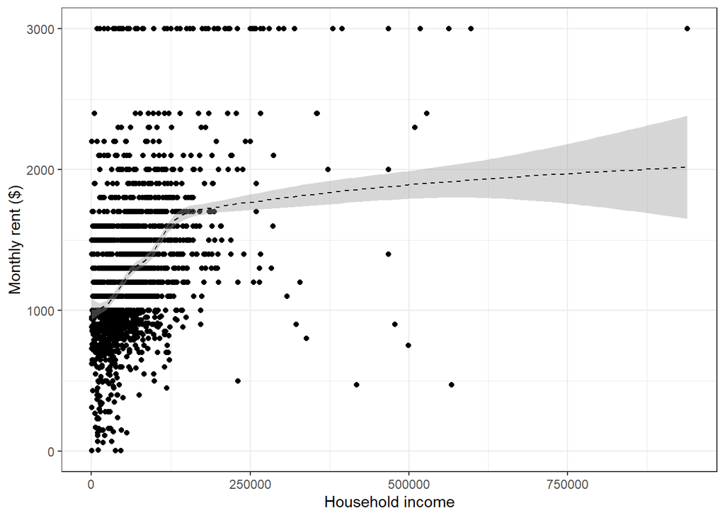

```r
ggplot(Travis_puma_rentals,
       aes(x = HINCP,
           y = RNTP)) +
  geom_point() +
  stat_smooth(color = "black", linetype = 2, size = 0.5) +
  scale_x_continuous(name = "Household income") +
  scale_y_continuous(name = "Monthly rent ($)") +
  theme_bw() +
  ggsave("A_1_scatterplot.png", width = 5, height = 5)
```

### 3. Similar scatterplot, set on a logarithmic scale:

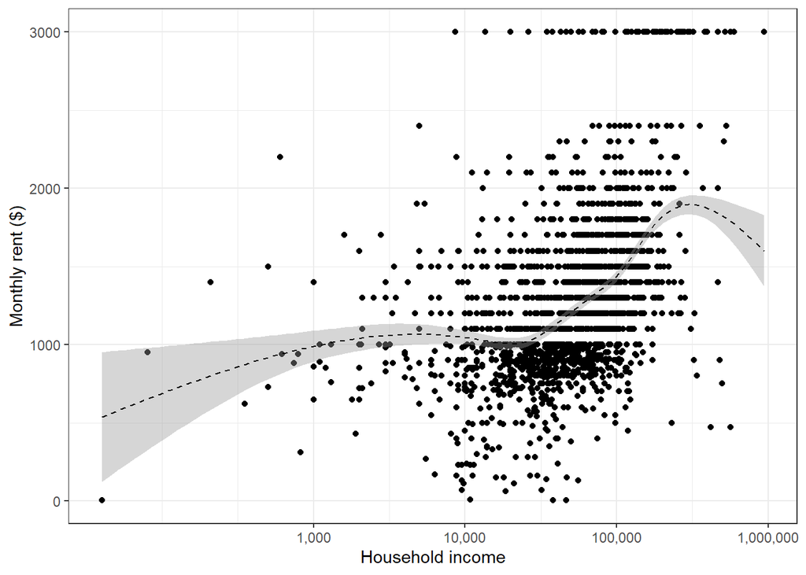

```r
ggplot(Travis_puma_rentals,
       aes(x = HINCP,
           y = RNTP)) +
  geom_point() +
  stat_smooth(color = "black", linetype = 2, size = 0.5) +
  scale_x_continuous(name = "Household income",
                             trans = "log",
                             breaks = c(1000, 10000, 100000, 1000000),
                             labels = c("1,000", "10,000", "100,000", "1,000,000")) +
  scale_y_continuous(name = "Monthly rent ($)") +
  theme_bw() +
  ggsave("A_2_scatterplot.png", width = 5, height = 5)
```

### 4. Same data as *3*, but set on a polar coordinate system:

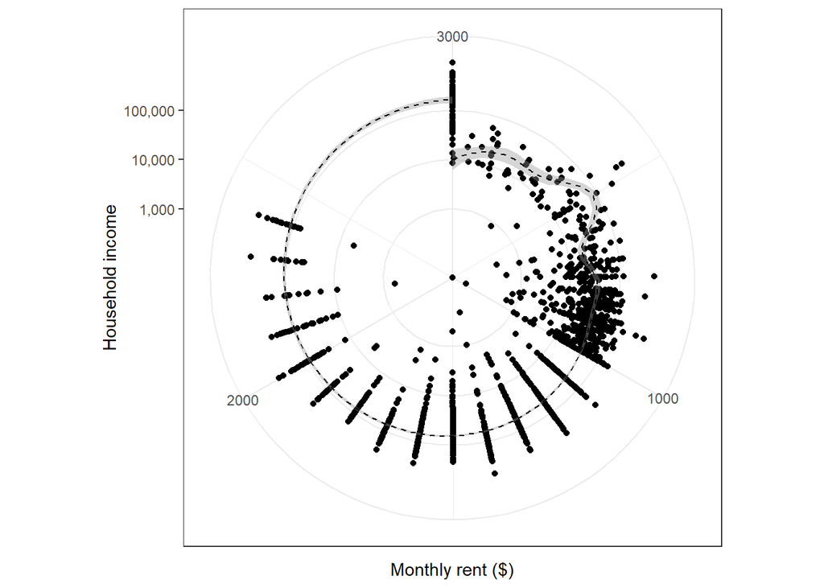

```r
ggplot(Travis_puma_rentals,
       aes(x = RNTP,
           y = HINCP)) +
  geom_point() +
  stat_smooth(color = "black", linetype = 2, size = 0.5) +
  scale_y_continuous(name = "Household income",
                     trans = "log",
                     breaks = c(1000, 10000, 100000, 1000000),
                     labels = c("1,000", "10,000", "100,000", "1,000,000")) +
  scale_x_continuous(name = "Monthly rent ($)") +
  coord_polar(theta = "x") +
  theme_bw() +
  ggsave("A_3_polarplot.png", width = 5, height = 5)
```

### 5. Household type and monthly rent represented via “binned” scatterplot:

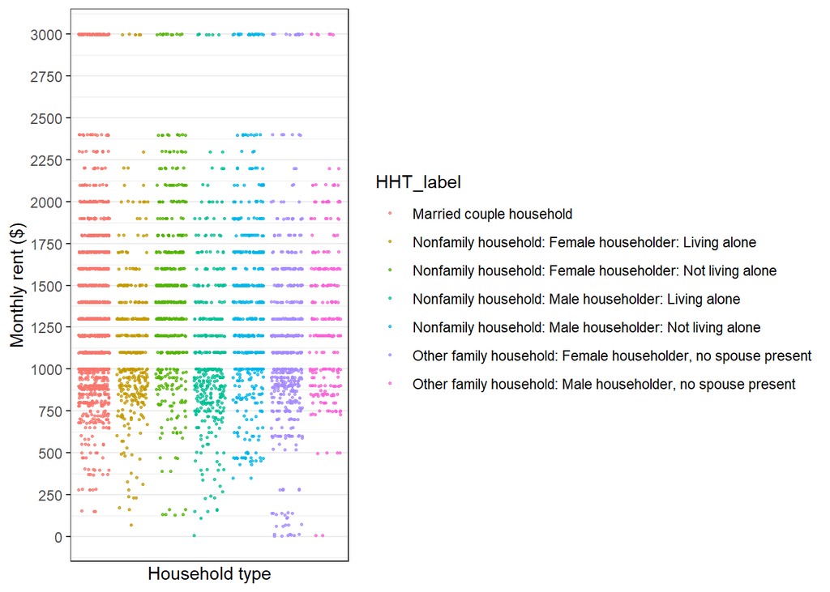

```r
ggplot(Travis_puma_rentals,
       aes(x = HHT_label,
           y = RNTP,
           color = HHT_label)) +
  geom_point(position = "jitter",
             size = 0.5,
             alpha = 0.75) +
  scale_x_discrete(name = "Household type",
                   theme(axis.text.x = element_blank())) +
  scale_y_continuous(name = "Monthly rent ($)",
                     breaks = seq(0, 3000, by = 250)) +
  theme_bw() +
  ggsave("A_4_jitterplot.png", width = 5, height = 5)
```

### 6. The same data as *5*, represented in a box plot:

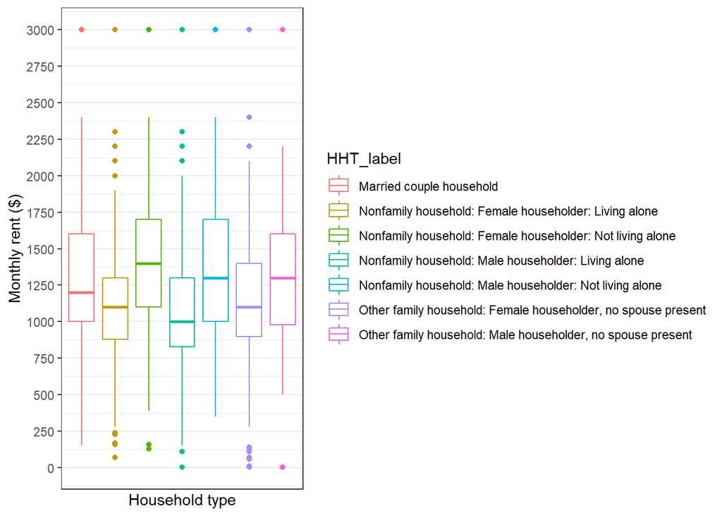

```r
ggplot(Travis_puma_rentals,
       aes(x = HHT_label,
           y = RNTP,
           color = HHT_label)) +
  geom_boxplot() +
  scale_x_discrete(name = "Household type",
                   theme(axis.text.x = element_blank())) +
  scale_y_continuous(name = "Monthly rent ($)",
                     breaks = seq(0, 3000, by = 250)) +
  theme_bw() +
  ggsave("A_1_boxplot.png", width = 5, height = 5)
```

### 7. A pie chart showing the humber of households in each housheold type category:

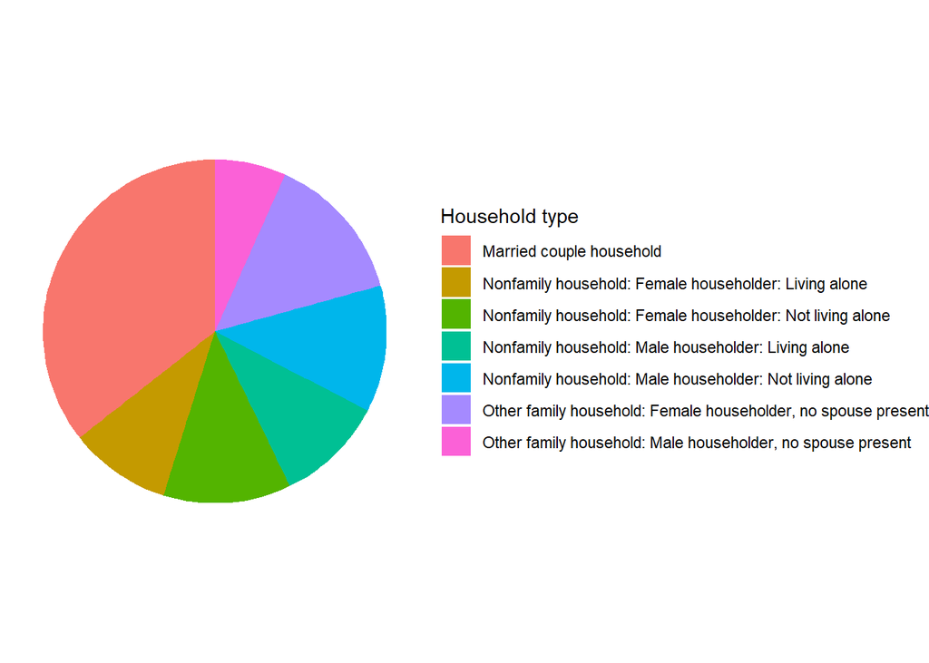

```r
pie_chart_1 <- ggplot(Travis_puma_rentals,
                      aes(x = 1, fill = HHT_label)) +
  geom_bar(position = "fill") +
  coord_polar(theta = "y") +
  scale_y_continuous(name = "Number of households") +
  scale_fill_discrete(name = "Household type") +
  theme_void()+
  ggsave("A_1_piechart.png", width = 5, height = 5)

pie_chart_1
```

### 8. Bar chart showing number of households, by type and year built:

- This chart presented a challenge in figuring out how to assign labels along the x axis - each cluster of bars should be labeled with a range of years. Unfortunately I tried a variety of different arguments and couldn’t solve this problem in time.

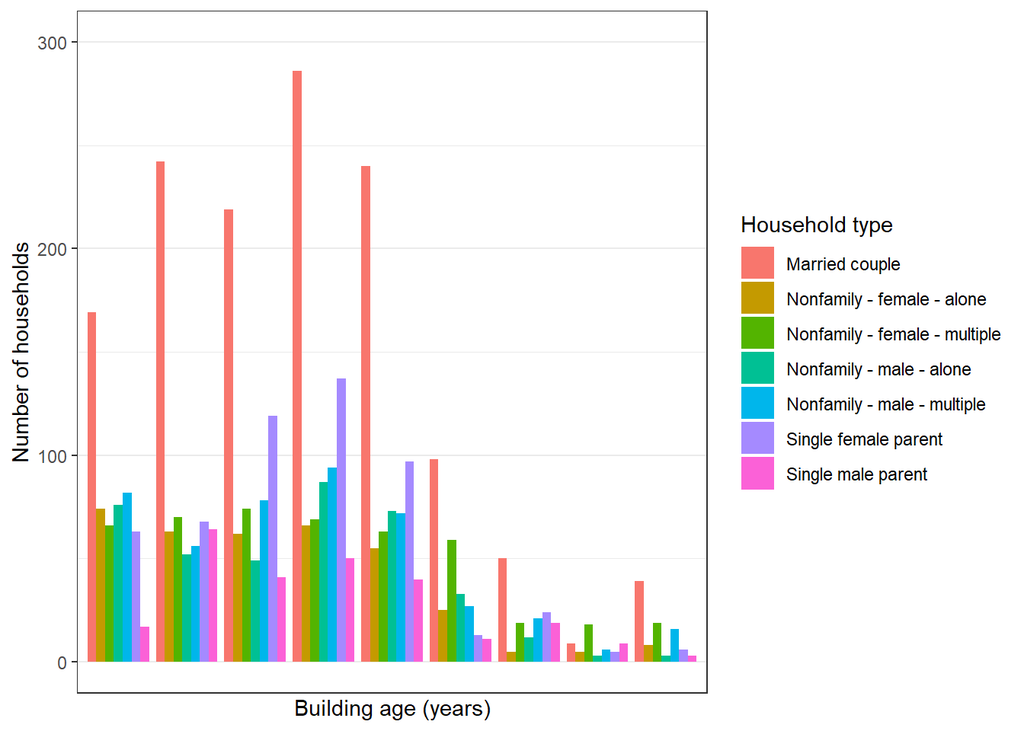

```r
ggplot(Travis_puma_rentals, aes(x = BLDG_AGE_dec, fill = HHT_label)) +
  geom_bar(position = "dodge") +
  scale_y_continuous(name = "Number of households") +
  scale_x_discrete(name = "Building age (years)",
                   labels = c("var_name" = "< 10",
                              "10-20",
                              "20-30",
                              "30-40",
                              "40-50",
                              "50-60",
                              "60-70",
                              "70-80",
                              "80+")) +
  scale_fill_discrete(name = "Household type",
                        labels = c("Married couple",
                                   "Nonfamily - female - alone",
                                   "Nonfamily - female - multiple",
                                   "Nonfamily - male - alone",
                                   "Nonfamily - male - multiple",
                                   "Single female parent",
                                   "Single male parent")) +
  theme_bw() +
  coord_cartesian(xlim = c(0, 8),
                  ylim = c(0, 300)) +
  ggsave("A_1_clusterbar.png", width = 5, height = 5)
```

- Yet again, this chart type presented difficulties. I may simply be using the wrong variables for this typology, but unfortunately my time has cut close and I want to explore another type.

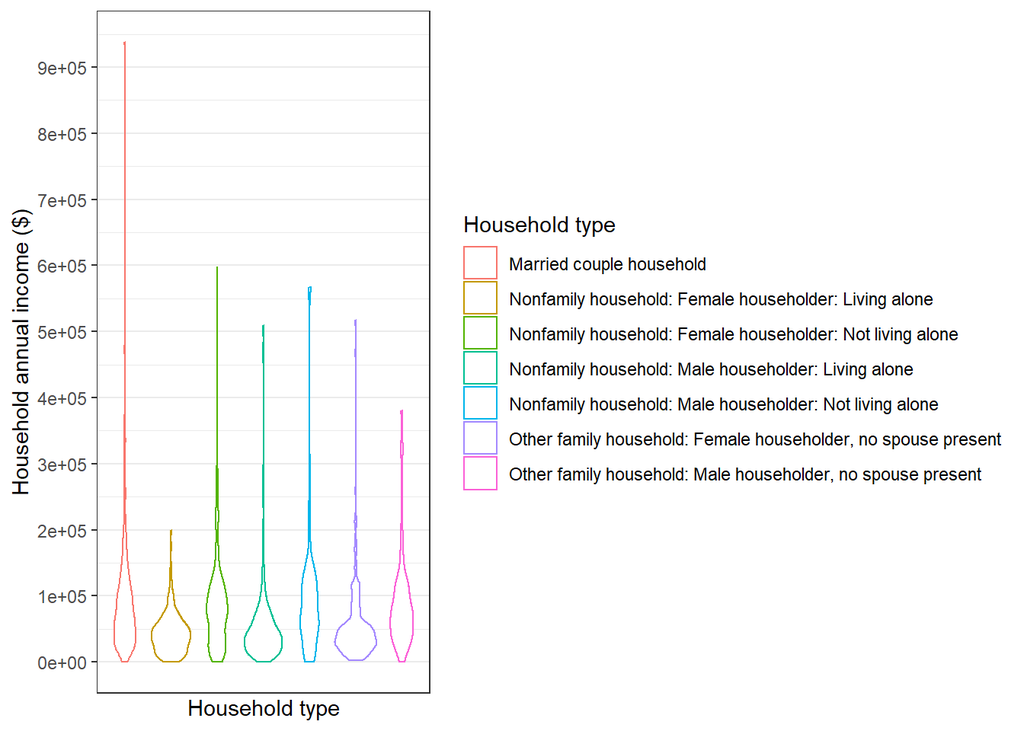

```r
ggplot(Travis_puma_rentals,
       aes(x = HHT_label,
           y = HINCP,
           color = HHT_label)) +
  geom_violin() +
  scale_x_discrete(name = "Household type", element_blank()) +
  scale_color_discrete(name = "Household type") +
  scale_y_continuous(name = "Household annual income ($)",
                     breaks = seq(0, 1000000, by = 100000)) +
  theme_bw()
```

### 10. Heatmap comparing household income and monthly rent:

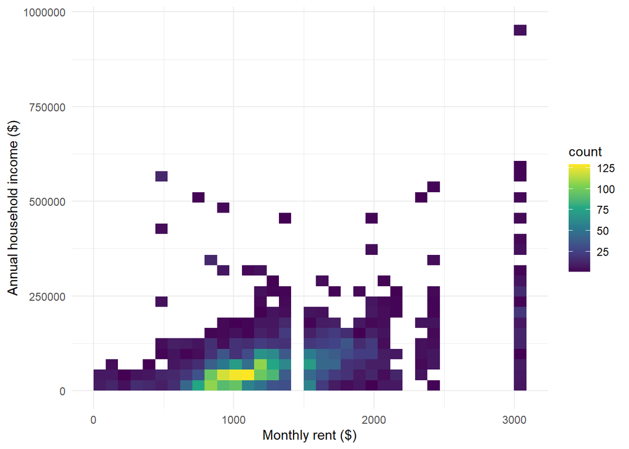

```r
ggplot(Travis_puma_rentals, aes(y=HINCP, x=RNTP)) +
  geom_bin2d(bins = 34) +
  scale_fill_continuous(type = "viridis") +
  scale_y_continuous(name = "Annual household income ($)") +
  scale_x_continuous(name = "Monthly rent ($)") +
  theme_minimal()
```